# R Notebook

# Chapter 11. Data visualization principles

Some general principles we can use as a guide for effective data visualization

some examples of plot styles we should avoid, explain how to improve them

**when deciding on a visualization approach, it is also important to keep out goal in mind** 목적과 대상

```r
library(tidyverse)
library(dslabs)
library(gridExtra)
```

# 11.1 Encoding data using visual cue

Suppose we want to report the results from two hypothetical polls regarding browser preference taken in 2000 and then 2015. For each year, we are simply comparing four quantities – the four percentages.

*pie chart* - representing quantities with areas and angles -> sub-optimal choice.

*donut chart* - only area

the ‘pie’ R functio help file states that: Pie charts are a very bad way of displaying information. The eye is good at judging linear measures and bad at judging relative areas. A bar chart or dot chart is a preferable way of displaying this type of data.

The preferred way to plot these quantities is to use length and position as visual cues. - *barplot*, and adding horizontal lines at every multiple of 10

If for some reason you need to make a pie chart, label each pie slice with its respective percentage

**In general, when displaying quantities, position and length are preferred over angles and/or area. But sometimes useful when more than two dimensions must be displayed at once**

# 11.2 Know when to include 0

Barplots - misinformative not to start the base at 0: we are implying the length is proportional to the quantities being displayed

Media use this to exaggerate the rate

When using position rather than length, not necessary to include 0

https://rafalab.github.io/dsbook/book_files/figure-html/points-plot-not-from-zero-1.png

# 11.3 Do not distort quantities

https://rafalab.github.io/dsbook/dataviz/img/class2_30.jpg

The reason for this distortion is that the radius, rather than the area, was made to be proportional to the quantity, which implies that the proportion between the areas is squared

ggplot2 defaults to using area rather than radius 똑똑하당

# 11.4 Order Categories by a meaningful value

When one of the axes show categories(character strings), the default ggplot2 behavior : order arphabetically

if defined by factors - ordered by factor levels -> 일반적으로 value값 순으로 정렬 - 비교도 쉽게

‘reorder’ function

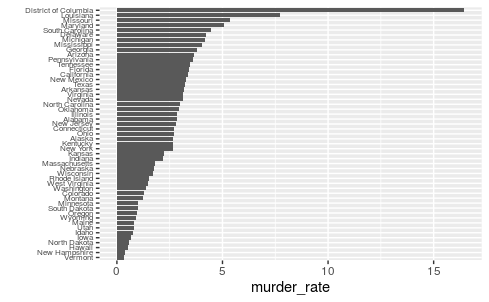

```r
data(murders)
murders %>% mutate(murder_rate = total / population * 100000) %>%
  mutate(state = reorder(state, murder_rate)) %>%
  ggplot(aes(state, murder_rate)) +
  geom_bar(stat="identity") +
  coord_flip() +
  theme(axis.text.y = element_text(size = 6)) +
  xlab("")
```

‘reorder’ lets us reorder groups as well

# 11.5 Show the data

comparing groups

ET is interested in the difference in heights btwn males and females

dynamite plot; shows the average(top of each bar) and standard errors(antennae extend out from the average to the average plus two standard errors)

showing all the data points

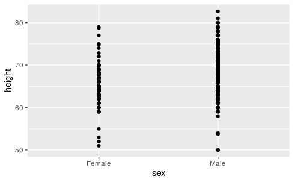

```r
heights %>%
  ggplot(aes(sex, height)) +
  geom_point()
```

- gives idea of the range of the data
- cannot see all the points respectively

How to improve? 1) *Jitter*, small randrom shift of each point: minimize the number of points that overlap 2) *Alpha Blending*, making points somewhat transparent: gets darker when overlapped so can see the distribution

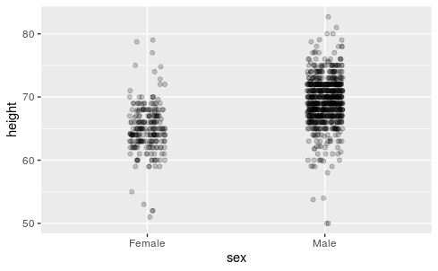

```r
heights %>%
  ggplot(aes(sex, height)) +
  geom_jitter(width = 0.1, alpha = 0.2)
```

# 11.6 Ease comparisons

## 11.6.1 Use common axes

It’s more effective to show distributions rather than individual points

histograms; **keeping the axes the same** when you are comparing

## 11.6.2 Align plots vertically to see horizontal changes and horizontally to see vertical changes

Aligning the plots vertically helpss us see the change when the axes are fixed

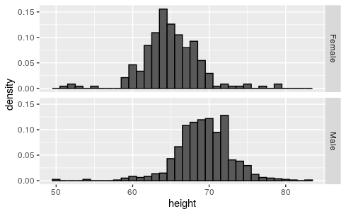

```r
heights %>%
  ggplot(aes(height, ..density..)) +
  geom_histogram(binwidth = 1, color="black") +
  facet_grid(sex~.)
```

boxplots & overlay data points

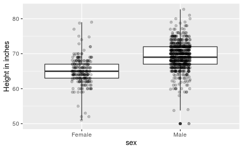

```r
heights %>%
  ggplot(aes(sex, height)) +
  geom_boxplot(coef=3) +
  geom_jitter(width = 0.1, alpha = 0.2) +
  ylab("Height in inches")
```

## 11.6.3 Consider transformations

The combination of incorrectly chosen barplot and a failure to use a log transformation when one is mertied ::: Disaster

Using a log transformation can provide a much more informative plot

logistic transformation ‘logit’ is useful to better see fold changes in odds, and the ‘sqrt’

## 11.6.4 Visual cues to be compared should be adjacent

For each continent, compare income in 1970 versus 2010

default : order labels alphabetically, so 1970s gather together, 2010s gather together -> would be better when 1970 and 2010 from same continent are next to each other

## 11.6.5 Use color

comparison becomes easier

# 11.7 Think of the color blind

| color_blind_friendly_cols <- |
| --- |
| c(“#999999”, “#E69F00”, “#56B4E9”, “#009E73”, |
| “#F0E442”, “#0072B2”, “#D55E00”, “#CC79A7”) |

https://bconnelly.net/posts/creating_colorblind-friendly_figures/

# 11.8 Plots for two variables

You should use scatterplots to visualize the relationship between two variables

Alternatives: *slope chart*, *bland-altman plot*

## 11.8.1 Slope Charts

When you are comparing variables of the same type, but at different time points and for a relatively small number of comparisons : another type of plot may be more informative

**Slope Chart**

we can construct using ‘geom_line’

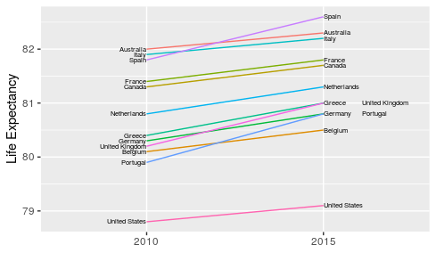

```r
west <- c("Western Europe","Northern Europe","Southern Europe",
          "Northern America","Australia and New Zealand")

dat <- gapminder %>%
  filter(year%in% c(2010, 2015) & region %in% west &
           !is.na(life_expectancy) & population > 10^7)

dat %>%
  mutate(location = ifelse(year == 2010, 1, 2),
         location = ifelse(year == 2015 &
                             country %in% c("United Kingdom","Portugal"),
                           location+0.22, location),
         hjust = ifelse(year == 2010, 1, 0)) %>%
  mutate(year = as.factor(year)) %>%
  ggplot(aes(year, life_expectancy, group = country)) +
  geom_line(aes(color = country), show.legend = FALSE) +
  geom_text(aes(x = location, label = country, hjust = hjust),
            show.legend = FALSE, size= 2) +
  xlab("") +
  ylab("Life Expectancy")
```

permits us to quickly get an idea of changes based on the slope of the lines angle - visual cue, we also have position to determine the exact values

**https://rafalab.github.io/dsbook/book_files/figure-html/scatter-plot-instead-of-slope-1.png**

bit harder to compare with scatterplot

## 11.8.2 Bland-altman plot

Dedicate one of axes to ‘difference’

[figure not shown]

```r
library(ggrepel)
dat %>%
   mutate(year = paste0("life_expectancy_", year)) %>%
   select(country, year, life_expectancy) %>% spread(year, life_expectancy) %>%
  mutate(average = (life_expectancy_2015 + life_expectancy_2010)/2,
         difference = life_expectancy_2015 - life_expectancy_2010) %>%
  ggplot(aes(average, difference, label = country)) +
  geom_point() +
  geom_text_repel() +
  geom_abline(lty = 2) +
  xlab("Average of 2010 and 2015") +
  ylab("Difference between 2015 and 2010")
```

looking at y-axis: quickly see which countries have shown the most improvement, x-axis: idea of overall value

# 11.9 Encoding a third variable

Three variables categorical values controlled by color and shape : ‘shape’ argument

https://rafalab.github.io/dsbook/book_files/figure-html/available-shapes-1.png

For continuous variables we use color, intensity, size

For a numerica value, there’s ‘sequential’ and ‘diverging’ sequential colors: suited for data that goes from high to low

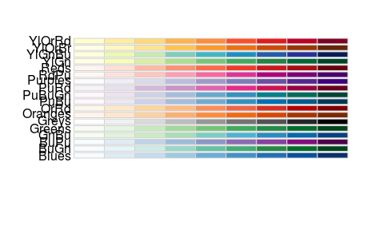

```r
library(RColorBrewer)
display.brewer.all(type="seq")
```

Diverging colors: used to represent values that diverge from a center, equal emphasis on both ends of the data range: average로부터 떨어진 정도가 중요할 때

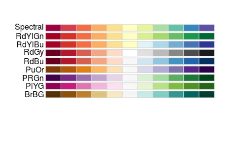

```r
library(RColorBrewer)
display.brewer.all(type="div")
```

# 11.10 Avoid pseudo-three-dimensional plots

Humans are not good at seeing in three dimensions, evern worse with pseudo-three-dimensions We easily use color to represent categorical variable instead of using a pseudo-3D

# 11.11 Avoid too many significant digits

7 Significant digits in R: often adds no information and can confuse viewers

state year Measles Pertussis Polio California 1940 37.8826320 18.3397861 18.3397861 California 1950 13.9124205 4.7467350 4.7467350 California 1960 14.1386471 0.0000000 0.0000000 California 1970 0.9767889 0.0000000 0.0000000 California 1980 0.3743467 0.0515466 0.0515466

reporting precision up to 0.00001 cases / 10,000 : very small two significant figures is more than enough and makes the point that rates are decreasing

state year Measles Pertussis Polio California 1940 37.9 18.3 18.3 California 1950 13.9 4.7 4.7 California 1960 14.1 0.0 0.0 California 1970 1.0 0.0 0.0 California 1980 0.4 0.1 0.1

use ‘signif’ and ‘round’ to change the number of significant digits or to round numbers ‘options(digits=3)’ define the number of significant digits

Place values being compared on columns rather than rows

# 11.12 Know your Audience

Graphs can is used for 1) data analysis, 2) convey message to experts, 3) for general audience

# 11.13 Exercises

```r
library(dslabs)
data(us_contagious_diseases)
```

1. Pie charts are appropriate:

A. When we want to display percentages.

B. When ggplot2 is not available.

C. When I am in a bakery.

**D. Never. Barplots and tables are always better.**

2. What is the problem with the plot below:

https://rafalab.github.io/dsbook/book_files/figure-html/baplot-not-from-zero-exercises-1.png

A. The values are wrong. The final vote was 306 to 232.

**B. The axis does not start at 0. Judging by the length, it appears Trump received 3 times as many votes when, in fact, it was about 30% more.**

C. The colors should be the same.

D. Percentages should be shown as a pie chart.

3. Take a look at the following two plots. They show the same information: 1928 rates of measles across the 50 states.

https://rafalab.github.io/dsbook/book_files/figure-html/measels-exercise-1.png

Which plot is easier to read if you are interested in determining which are the best and worst states in terms of rates, and why?

A. They provide the same information, so they are both equally as good.

B. The plot on the right is better because it orders the states alphabetically.

**C. The plot on the right is better because alphabetical order has nothing to do with the disease and by ordering according to actual rate, we quickly see the states with most and least rates.**

D. Both plots should be a pie chart.

4. To make the plot on the left, we have to reorder the levels of the states’ variables.

```r
dat <- us_contagious_diseases %>%
  filter(year == 1967 & disease=="Measles" & !is.na(population)) %>%
  mutate(rate = count / population * 10000 * 52 / weeks_reporting)
```

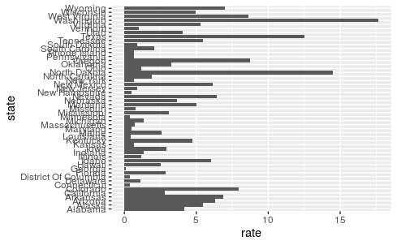

```r
dat %>% ggplot(aes(state, rate)) +
  geom_bar(stat="identity") +
  coord_flip()
```

Define these objects:

```r
state <- dat$state
rate <- dat$count/dat$population*10000*52/dat$weeks_reporting
```

Redefine the state object so that the levels are re-ordered. Print the new object state and its levels so you can see that the vector is not re-ordered by the levels.

```r
state <- reorder(state, rate)
state
```

```
 [1] Alabama              Alaska
 [3] Arizona              Arkansas
 [5] California           Colorado
 [7] Connecticut          Delaware
 [9] District Of Columbia Florida
[11] Georgia              Hawaii
[13] Idaho                Illinois
[15] Indiana              Iowa
[17] Kansas               Kentucky
[19] Louisiana            Maine
[21] Maryland             Massachusetts
[23] Michigan             Minnesota
[25] Mississippi          Missouri
[27] Montana              Nebraska
[29] Nevada               New Hampshire
[31] New Jersey           New Mexico
[33] New York             North Carolina
[35] North Dakota         Ohio
[37] Oklahoma             Oregon
[39] Pennsylvania         Rhode Island
[41] South Carolina       South Dakota
[43] Tennessee            Texas
[45] Utah                 Vermont
[47] Virginia             Washington
[49] West Virginia        Wisconsin
[51] Wyoming
attr(,"scores")
             Georgia District Of Columbia
          0.09987991           0.35873614
         Connecticut            Minnesota
          0.36986840           0.37722410
           Louisiana        New Hampshire
          0.46088071           0.47181511
            Maryland               Kansas
          0.49922233           0.66386422
            New York         Pennsylvania
          0.66849058           0.67687303
        Rhode Island        Massachusetts
          0.68207448           0.74762338
            Missouri           New Jersey
```

[output cut: 25 more lines]

```
           Tennessee                Idaho
          5.47344506           6.03115170
          New Mexico              Arizona
          6.15969926           6.32695891
              Nevada             Arkansas
          6.43683882           6.87899954
             Wyoming             Colorado
          6.97303449           7.96331905
       West Virginia               Oregon
          8.59456463           8.75036439
               Texas         North Dakota
         12.49773953          14.48024642
          Washington
         17.65180349
51 Levels: Georgia District Of Columbia ... Washington
```

```r
levels(state)
```

```
 [1] "Georgia"              "District Of Columbia"
 [3] "Connecticut"          "Minnesota"
 [5] "Louisiana"            "New Hampshire"
 [7] "Maryland"             "Kansas"
 [9] "New York"             "Pennsylvania"
[11] "Rhode Island"         "Massachusetts"
[13] "Missouri"             "New Jersey"
[15] "South Dakota"         "Vermont"
[17] "Delaware"             "Ohio"
[19] "Illinois"             "Michigan"
[21] "Indiana"              "North Carolina"
[23] "South Carolina"       "Hawaii"
[25] "Maine"                "California"
[27] "Florida"              "Iowa"
[29] "Mississippi"          "Oklahoma"
[31] "Nebraska"             "Utah"
[33] "Alabama"              "Kentucky"
[35] "Wisconsin"            "Montana"
[37] "Virginia"             "Alaska"
[39] "Tennessee"            "Idaho"
[41] "New Mexico"           "Arizona"
[43] "Nevada"               "Arkansas"
[45] "Wyoming"              "Colorado"
[47] "West Virginia"        "Oregon"
[49] "Texas"                "North Dakota"
[51] "Washington"
```

5. Now with one line of code, define the dat table as done above, but change the use mutate to create a rate variable and reorder the state variable so that the levels are reordered by this variable. Then make a barplot using the code above, but for this new dat.

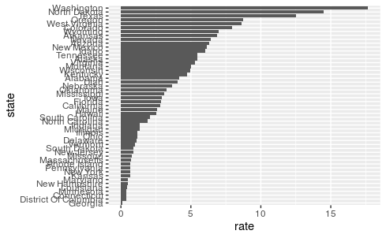

```r
dat <- us_contagious_diseases %>% filter(year== 1967 & disease=="Measles" & !is.na(population)) %>% mutate(rate=count/population*10000*52/weeks_reporting) %>% mutate(state=reorder(state,rate))

dat %>% ggplot(aes(state, rate)) + geom_bar(stat="identity") + coord_flip()
```

```r
# If you want the heights of the bars to represent values in the data, use stat="identity" and map a value to the y aesthetic.
```

6. Say we are interested in comparing gun homicide rates across regions of the US. We see this plot:

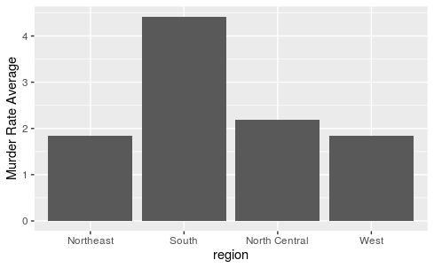

```r
library(dslabs)
data("murders")
murders %>% mutate(rate = total/population*100000) %>%
  group_by(region) %>%
  summarize(avg = mean(rate)) %>%
  mutate(region = factor(region)) %>%
  ggplot(aes(region, avg)) +
  geom_bar(stat="identity") +
  ylab("Murder Rate Average")
```

and decide to move to a state in the western region. What is the main problem with this interpretation?

A. The categories are ordered alphabetically.

B. The graph does not show standard errors.

**C. It does not show all the data. We do not see the variability within a region and it’s possible that the safest states are not in the West.**

D. The Northeast has the lowest average.

7. Make a boxplot of the murder rates defined as

```r
data("murders")
murders %>% mutate(rate = total/population*100000)
```

| state | abb | region | population | total | rate |
| --- | --- | --- | --- | --- | --- |
| Alabama | AL | South | 4779736 | 135 | 2.8244238 |
| Alaska | AK | West | 710231 | 19 | 2.6751860 |
| Arizona | AZ | West | 6392017 | 232 | 3.6295273 |
| Arkansas | AR | South | 2915918 | 93 | 3.1893901 |
| California | CA | West | 37253956 | 1257 | 3.3741383 |
| Colorado | CO | West | 5029196 | 65 | 1.2924531 |
| Connecticut | CT | Northeast | 3574097 | 97 | 2.7139722 |
| Delaware | DE | South | 897934 | 38 | 4.2319369 |
| District of Columbia | DC | South | 601723 | 99 | 16.4527532 |
| Florida | FL | South | 19687653 | 669 | 3.3980688 |

[output cut: 41 more lines]

by region, showing all the points and ordering the regions by their median rate.

[figure not shown]

```r
murders %>% mutate(region=reorder(region, rate, median)) %>% ggplot(aes(region, rate)) + geom_boxplot() + geom_jitter(width=0.2, alpha=0.3) + xlab("Region") + ylab("Murder Rates")
```

8. The plots below show three continuous variables.

https://rafalab.github.io/dsbook/book_files/figure-html/pseudo-3d-exercise-1.png

The line $x=2$ appears to separate the points. But it is actually not the case, which we can see by plotting the data in a couple of two dimensional points.

https://rafalab.github.io/dsbook/book_files/figure-html/pseud-3d-exercise-2-1.png

Why is this happening?

**A. Humans are not good at reading pseudo-3D plots.**

B. There must be an error in the code.

C. The colors confuse us.

D. Scatterplots should not be used to compare two variables when we have access to 3.

9번~12번까지는 11.15 Exercise 내용이라 생략했습니다.

# 11.14 Case study: impact of vaccines on battling infectious diseases

## Vaccination

1988 paper : There’s a link btwn administration of measles, mumps and rubella vaccine and the appearance of autism and bowel disease. -> misconceptions persist

Center for Disease Control (CDC) estimates that vaccinations will prevent more than 21 million hospitalizations and 732,000 deaths among children born in the last 20 years.

The data used for these plots were collected, organized and distributed by the Tycho Project, include weekly reported counts for seven diseases from 1928 to 2011, from all fifty states.

```r
library(tidyverse)
library(dslabs)
data(us_contagious_diseases)
str(us_contagious_diseases)
```

```
'data.frame':   18870 obs. of  6 variables:
 $ disease        : Factor w/ 7 levels "Hepatitis A",..: 1 1 1 1 1 1 1 1 1 1 ...
 $ state          : Factor w/ 51 levels "Alabama","Alaska",..: 1 1 1 1 1 1 1 1 1 1 ...
 $ year           : num  1966 1967 1968 1969 1970 ...
 $ weeks_reporting: int  50 49 52 49 51 51 45 45 45 46 ...
 $ count          : num  321 291 314 380 413 378 342 467 244 286 ...
 $ population     : num  3345787 3364130 3386068 3412450 3444165 ...
```

```r
the_disease <- "Measles"
dat <- us_contagious_diseases %>%
  filter(!state%in%c("Hawaii","Alaska") & disease == the_disease) %>%
  mutate(rate = count / population * 10000 * 52 / weeks_reporting) %>%
  mutate(state = reorder(state, rate))
```

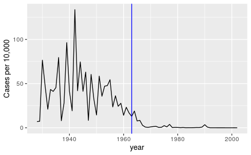

```r
dat %>% filter(state == "California" & !is.na(rate)) %>%
  ggplot(aes(year, rate)) +
  geom_line() +
  ylab("Cases per 10,000")  +
  geom_vline(xintercept=1963, col = "blue")
```

Added a vertical line at 1963 since this is when the vaccine was introduced

Now, we have three variables to show: year, state and rate. Sequential palette ; no meaningful center

‘geom_tile’ to tile the region with colors representing disease rates, use square root transformation, missing values are grey

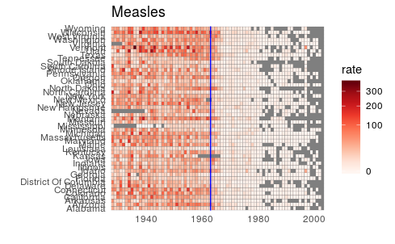

```r
dat %>% ggplot(aes(year, state, fill = rate)) +
  geom_tile(color = "grey50") +
  scale_x_continuous(expand=c(0,0)) +
  scale_fill_gradientn(colors = RColorBrewer::brewer.pal(9, "Reds"), trans = "sqrt") +
  geom_vline(xintercept=1963, col = "blue") +
  theme_minimal() +  theme(panel.grid = element_blank()) +
  ggtitle(the_disease) +
  ylab("") +
  xlab("")
```

limitation; colors represent quantity, makes it harder to know exactly how high values are going. Position and Length are better clues.

```r
avg <- us_contagious_diseases %>%
  filter(disease==the_disease) %>% group_by(year) %>%
  summarize(us_rate = sum(count, na.rm=TRUE)/sum(population, na.rm=TRUE)*10000)
```

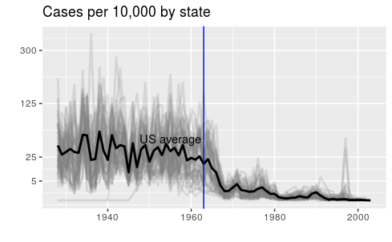

```r
dat %>%
  filter(!is.na(rate)) %>%
    ggplot() +
  geom_line(aes(year, rate, group = state),  color = "grey50",
            show.legend = FALSE, alpha = 0.2, size = 1) +
  geom_line(mapping = aes(year, us_rate),  data = avg, size = 1, color = "black") +
  scale_y_continuous(trans = "sqrt", breaks = c(5, 25, 125, 300)) +
  ggtitle("Cases per 10,000 by state") +
  xlab("") +
  ylab("") +
  geom_text(data = data.frame(x = 1955, y = 50),
            mapping = aes(x, y, label="US average"),
            color="black") +
  geom_vline(xintercept=1963, col = "blue")
```

We can use color to represent categorical value state but hard to pick 50 distant colors

# 11.15 Exercises

1. Reproduce the image plot we previously made but for smallpox. For this plot, do not include years in which cases were not reported in 10 or more weeks.

[figure not shown]

```r
what_disease <- "Smallpox"
dat <- us_contagious_diseases %>%
  filter(!state%in%c("Hawaii","Alaska") & disease == what_disease & weeks_reporting>=10) %>%
  mutate(rate = count / population * 10000 * 52 / weeks_reporting) %>%
  mutate(state = reorder(state, rate))
dat %>% ggplot(aes(year, state, fill = rate)) +
  geom_tile(color = "grey50") +
  scale_x_continuous(expand=c(0,0)) +
  scale_fill_gradientn(colors = RColorBrewer::brewer.pal(9, "Greens"), trans = "sqrt") +
  theme_minimal() +  theme(panel.grid = element_blank()) +
  ggtitle(the_disease) +
  ylab("") +
  xlab("")
```

2. Now reproduce the time series plot we previously made, but this time following the instructions of the previous question for smallpox.

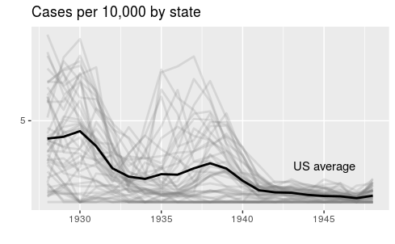

```r
avg <- us_contagious_diseases %>%
  filter(disease==what_disease & weeks_reporting>=10) %>% group_by(year) %>%
  summarize(us_rate = sum(count, na.rm=TRUE)/sum(population, na.rm=TRUE)*10000)

dat %>%
  filter(!is.na(rate)) %>%
    ggplot() +
  geom_line(aes(year, rate, group = state),  color = "grey50",
            show.legend = FALSE, alpha = 0.2, size = 1) +
  geom_line(mapping = aes(year, us_rate),  data = avg, size = 1, color = "black") +
  scale_y_continuous(trans = "sqrt", breaks = c(5, 25, 125, 300)) +
  ggtitle("Cases per 10,000 by state") +
  xlab("") +
  ylab("") +
  geom_text(data = data.frame(x = 1945, y = 1),
            mapping = aes(x, y, label="US average"),
            color="black")
```

3. For the state of California, make a time series plot showing rates for all diseases. Include only years with 10 or more weeks reporting. Use a different color for each disease.

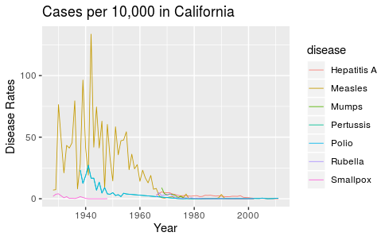

```r
us_contagious_diseases %>%
  filter(!is.na(rate), state == "California" & weeks_reporting>=10) %>% mutate(rate=count / population * 10000 * 52 / weeks_reporting) %>% ggplot() +  geom_line(aes(year, rate, color = disease), show.legend = TRUE, size = 0.3) +
  ggtitle("Cases per 10,000 in California") +
  xlab("Year") +
  ylab("Disease Rates")
```

4. Now do the same for the rates for the US. Hint: compute the US rate by using summarize: the total divided by total population.

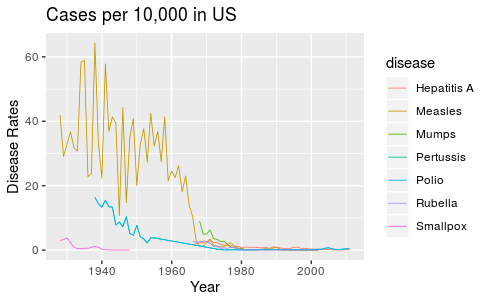

```r
us_contagious_diseases %>% filter(weeks_reporting>=10) %>% group_by(year, disease) %>% summarize(rate = sum(count, na.rm=TRUE)/sum(population, na.rm=TRUE)*10000) %>%  filter(!is.na(rate)) %>% ggplot() + geom_line(aes(year, rate, color = disease), show.legend = TRUE, size = 0.3) + ggtitle("Cases per 10,000 in US") +xlab("Year") + ylab("Disease Rates")
```